# Project Python Foundations: FoodHub Data Analysis

# **Food Preparation Time**

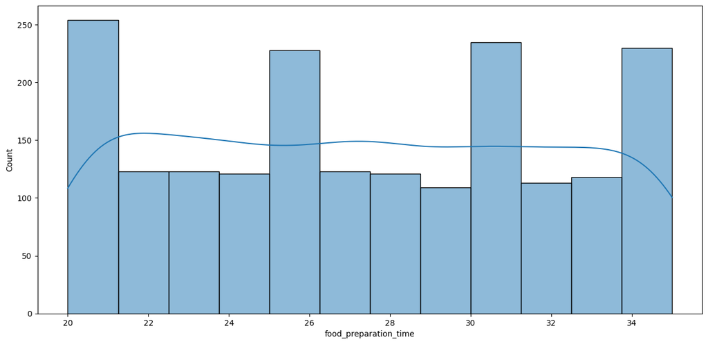

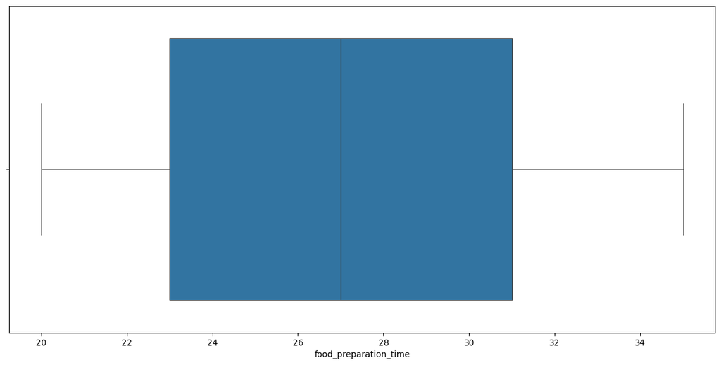

```python
plt.figure(figsize=(15,7))
sns.histplot(x='food_preparation_time',data=df,kde=True)
plt.show()

plt.figure(figsize=(15,7))
sns.boxplot(x='food_preparation_time',data=df)
plt.show()
```

### Observations:

Histplot: The food preparation time ranges between 20-35 mins.There are peaks at regular interval of 20, 25,30 and 35 mins.

The data is not normally distributed but has some peaks.

Boxplot: The median food prepation time is 27 mins. The data distribution is symmetric and the whiskers are almost of the same length. There are no visible outliers and no significant skew in the data.

# **Delivery Time**

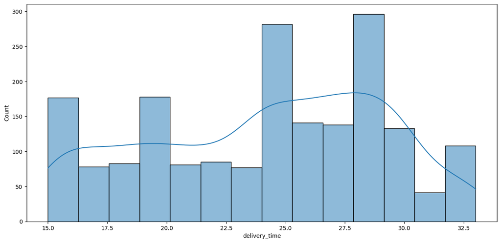

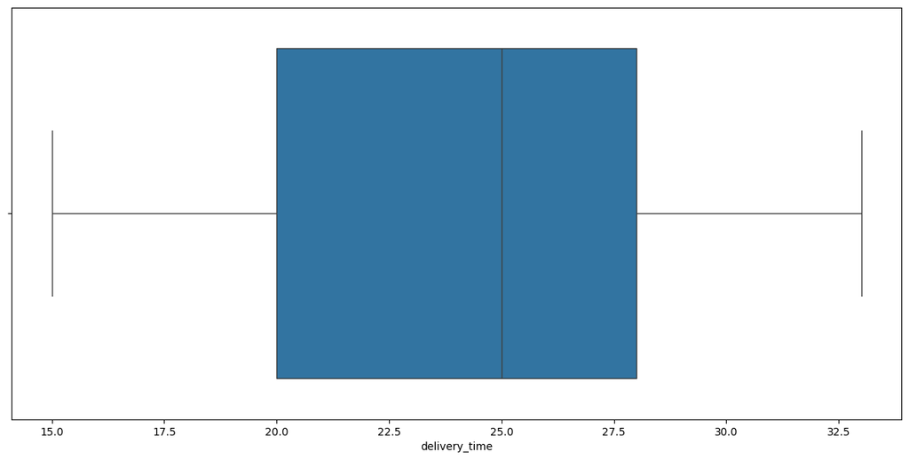

```python
plt.figure(figsize=(15,7))
sns.histplot(x='delivery_time',data=df,kde=True)
plt.show()

plt.figure(figsize=(15,7))
sns.boxplot(x='delivery_time',data=df)
plt.show()
```

### Observations

Histplot: The delivery time ranged from 15mins - 33mins. There are some peaks seen at 15,20,25 and 29 mins. There is a slight skew to the left in the data. Boxplot: The median delivery time is 25 mins and The IQR is between 20-28 mins. 50% of the orders are delivered in less than 25 mins. There are no visible outliers. The median is slightly towards the right and the mean is less than median indicating a mild left skew.

### **Question 7**: Which are the top 5 restaurants in terms of the number of orders received? [1 mark]

```python
order_count = df.groupby(['restaurant_name'])['order_id'].count()
order_count.sort_values(ascending=False).head()
```

| restaurant_name | order_id |
| --- | --- |
| Shake Shack | 219 |
| The Meatball Shop | 132 |
| Blue Ribbon Sushi | 119 |
| Blue Ribbon Fried Chicken | 96 |
| Parm | 68 |

**dtype:** int64

#### Observations:

The following are the top 5 restaurants in terms of the number of orders received.Shake Shack tops the list with 219 orders.

```
**Restaurant Name         | Total Orders Received**
--------------------------|-----------------------
Shake Shack               | 219
The Meatball Shop         | 132
Blue Ribbon Sushi         | 119
Blue Ribbon Fried Chicken | 96
Parm                      | 68
```

### **Question 8**: Which is the most popular cuisine on weekends? [1 mark]

```python
# Write the code here
df[df['day_of_the_week']=='Weekend'].cuisine_type.value_counts()
```

| cuisine_type | count |
| --- | --- |
| American | 415 |
| Japanese | 335 |
| Italian | 207 |
| Chinese | 163 |
| Mexican | 53 |
| Indian | 49 |
| Middle Eastern | 32 |
| Mediterranean | 32 |
| Thai | 15 |
| French | 13 |
| Korean | 11 |
| Southern | 11 |
| Spanish | 11 |
| Vietnamese | 4 |

**dtype:** int64

#### Observations:

The most popular cuisine type on weekends is American with a total weekend order count of 415.

### **Question 9**: What percentage of the orders cost more than 20 dollars? [2 marks]

```python
# Write the code here
df.head()
df_orders = df[df['cost_of_the_order']>20]
order_percent = df_orders['cost_of_the_order'].count()*100/len(df)
order_percent
```

```
np.float64(29.24130663856691)
```

#### Observations:

29.24 percentage of the orders cost more than 20 dollars.

### **Question 10**: What is the mean order delivery time? [1 mark]

```python
# Write the code here

df['delivery_time'].mean()
```

```
np.float64(24.161749209694417)
```

#### Observations:

The mean order delivery time is 24.16 minutes.

### **Question 11:** The company has decided to give 20% discount vouchers to the top 3 most frequent customers. Find the IDs of these customers and the number of orders they placed. [1 mark]

```python
# Write the code here
df['customer_id'].value_counts()
```

| customer_id | count |
| --- | --- |
| 52832 | 13 |
| 47440 | 10 |
| 83287 | 9 |
| 250494 | 8 |
| 259341 | 7 |
| ... | ... |
| 143926 | 1 |
| 89574 | 1 |
| 157711 | 1 |
| 66393 | 1 |
| 358141 | 1 |

1200 rows × 1 columns

**dtype:** int64

#### Observations:

The top three IDs of the most frequent customers are:

```
**ID          | Total number of orders**
--------------|------------------
52832         | 13
47440         | 10
83287         | 9
```

### **Question 12**: Perform a multivariate analysis to explore relationships between the important variables in the dataset. (It is a good idea to explore relations between numerical variables as well as relations between numerical and categorical variables) [10 marks]

## **Cuisine Type vs Cost of the Order**

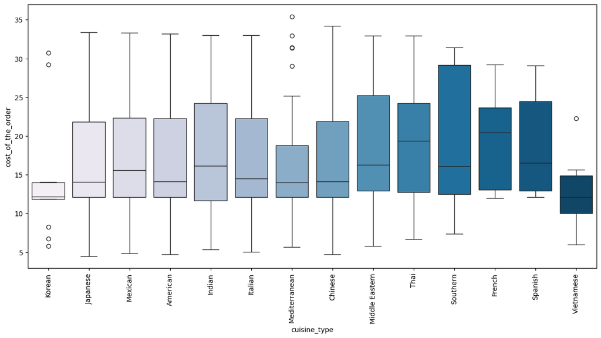

```python
plt.figure(figsize=(15,7))
sns.boxplot(x='cuisine_type',y='cost_of_the_order',data=df,palette = 'PuBu', hue = "cuisine_type")
plt.xticks(rotation=90)
plt.show()
```

## **Cuisine Type vs Food Preparation Time**

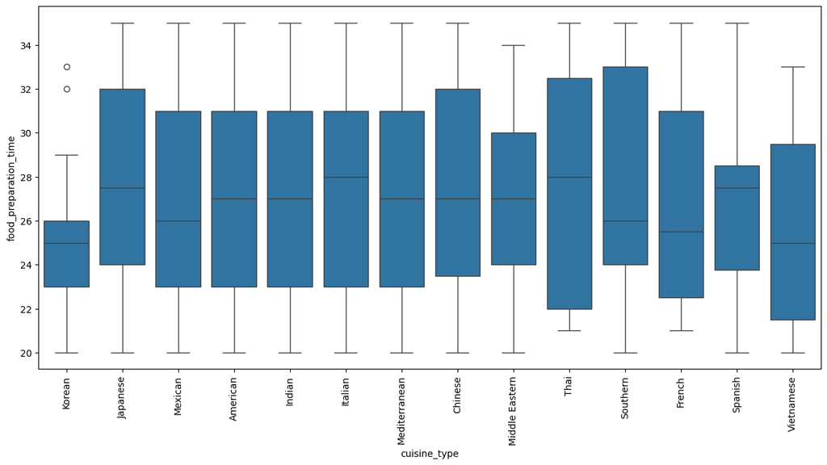

```python
plt.figure(figsize=(15,7))
sns.boxplot(x='cuisine_type',y='food_preparation_time',data=df)
plt.xticks(rotation=90)
plt.show()
```

### Observation

- Korean cuisine has the least median cooking time around 25 mins.
- Korean and Spanish have smaller IQR indicating less variation of cooking time across their orders.
- Thai and Southern cuisine have a larger spread indicating more variability in their cooking time.
- Most of the cuisines have median cooking time ranging between 26-28 mins and IQRs are fairly wide indicating moderate variation in cooking time.

## **Day of the Week vs Delivery Time**

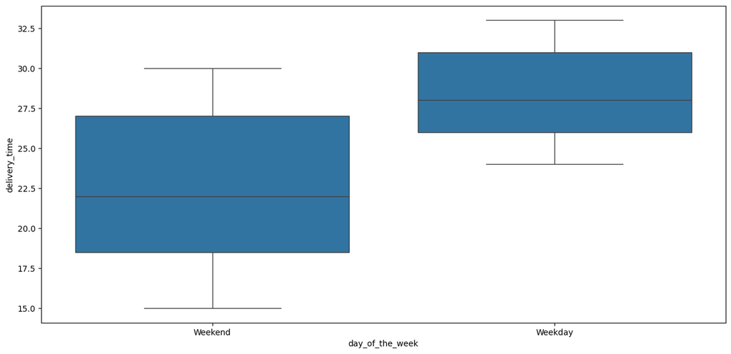

```python
plt.figure(figsize=(15,7))
sns.boxplot(x='day_of_the_week',y='delivery_time',data=df)
plt.show()
```

## **Rating vs Food preparation time**

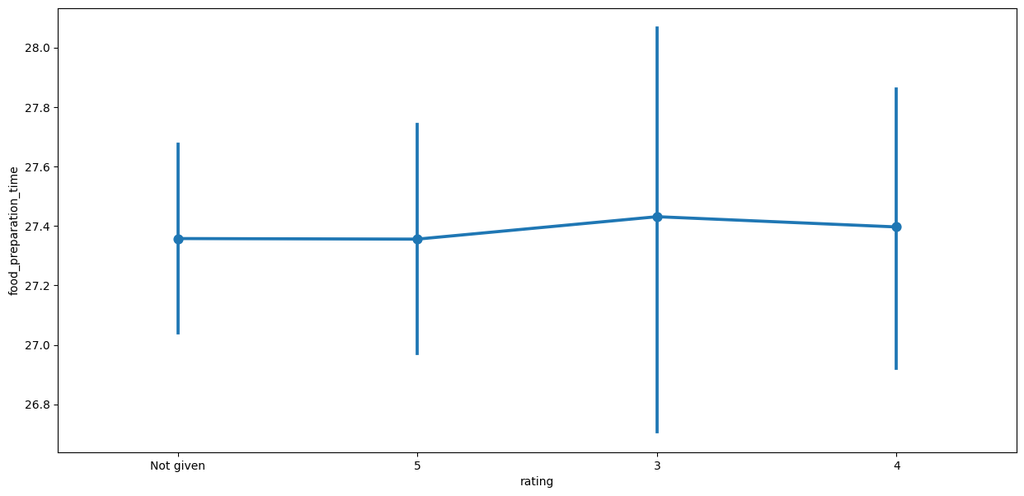

```python
plt.figure(figsize=(15,7))
sns.pointplot(x='rating',y='food_preparation_time',data=df)
plt.show()
```

### Observations

- The mean food preparation time is almost similar across different ratings. The mean time is approximately between 27.30 to 27.40 mins.
- The standard deviation or variability of mean time is higher for rating 3 indicating several orders with varying preparation time.
- The plot shows the the food preparation time does not affect the rating.

## **Rating vs Delivery Time**

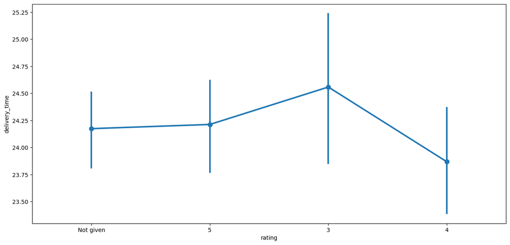

```python
plt.figure(figsize=(15,7))
sns.pointplot(x='rating',y='delivery_time',data=df)
plt.show()
```